# Methods 4 – Portfolio Assignment 2

*Note: Initials were added to the document as required but group work was done equally together.*

## Study group 8

- Kristian Villebro (KV): 202005289
- Luke Ring (LR): 202009983
- Vyara Krasteva (VK): 202005673
- *Type:* Group assignment
- *Due:* 3 April 2022, 23:59

Hello CogSci's :)

In this portfolio, you are asked to do four tasks:

\1. - Make a DAG for something

\2. - Simulate data that fits the DAG

\3. - Use linear models to confirm that the DAG fits the data

\4. - Mess it up.

Each of the four tasks have some sub-steps.  
***Report briefly what you find, for example in a markdown document, for example called report.md so that the poor TA can easily get an overview before looking in your code :)

Then you can also make a (brief!) explanation of the phenomenon you are DAGGIN, simulating and modelling.

Looking forward !

## Task 1: The DAG (KV)

- **Come up with an** incredibly interesting and scientifically important made-up **example** for a phenomenon to investigate. Decide on two variables (an outcome and a predictor) that you would like to investigate the relation between. If in doubt, you **can be inspired by Peter's amazing example** on the next page.

#As part of this portfolio assignment, we have come up with the undoubtedly very relatable and, thus, scientifically consequential simulated example of Dating_success # We are investigating a model which attempts to find what reinforcing effects certain variables have to a Date’s success. These variables are lister below. #Furthermore, we have created a DAG with the underlying types of relations between variables, that are assumed by our model.

#Description of the variables we include:

Variables are: Charm, Chemistry, Attractiveness, Libido, Activity and Date_success (outcome variable) All variables have been decided to be continous except *Activity* which is categorical. Variables are only related to one person in the dating dyad. That is, except for _Activity, which lists the shared types of activity that both parties engage in on the date.

```r
#loading libraries

library(rethinking)
library(dagitty)
set.seed(42)
```

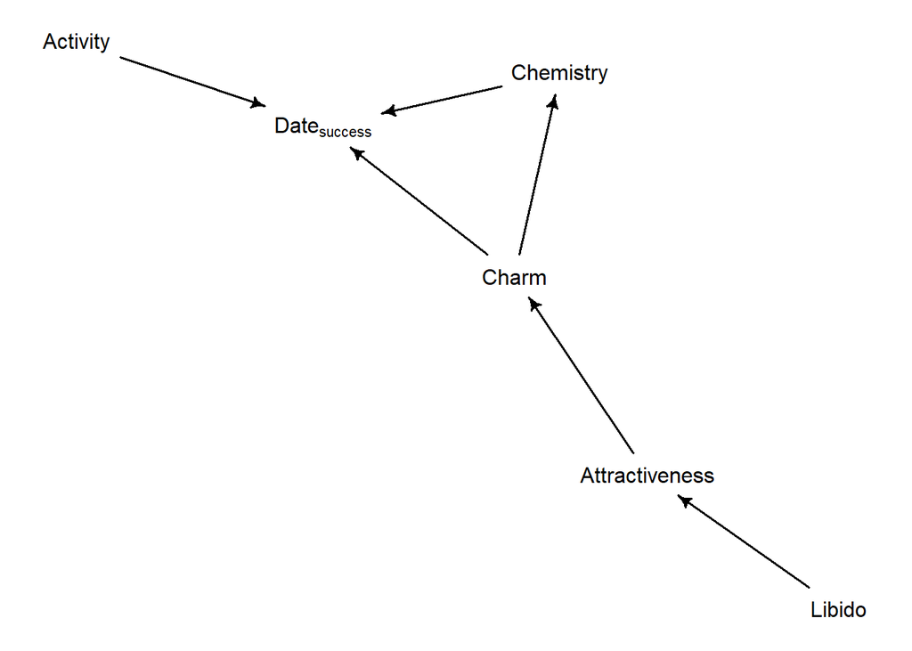

```r
#Make a Dag
Dag <- dagitty(
  "dag {
    Charm -> Chemistry -> Date_success
    Charm -> Date_success
    Activity -> Date_success
    Attractiveness -> Charm
    Libido -> Attractiveness
  }"
)

drawdag(Dag)
```

- Find **elemental forms of variable relations** in the DAG (i.e., forks, pipes, colliders, and their descendants).

In our imaginary DAG above, Date success is the Outcome variable which is influenced by a lot of variables.

Starting from the right side of the DAG: Libido is an independent variable. Attractiveness is in a pipe from Lib->Attra->Charm. Charm acts as a Fork, but is also part of a pipe. Chemistry is in a pipe. Activity is an independent variable. Date_success is a collider.

- Find out **what variables to include (and not include)** in a multiple linear regression to avoid 'back door' (AKA non-causal) paths. Do this first with your eyes and your mind. Then you can use dagitty's function `adjustmentSets()`.

```r
adjustmentSets(Dag, exposure = "Chemistry", outcome = "Date_success")
```

```
{ Charm }
```

```r
adjustmentSets(Dag,
  exposure = c("Activity", "Libido"),
  outcome = "Date_success")
```

```
 {}
```

As the function output shows, using Activity and Libido as predictors and Date Success as the outcome variable, we do not allow any backdoor paths, whereas if we would use Chemistry, then we would need to condition on Charm.

- Find out which **conditional independencies** the DAG implies. First with the mind, then with daggity's function `impliedConditionalIndependencies()`.

```r
impliedConditionalIndependencies(Dag)
```

```
Actv _||_ Attr
Actv _||_ Chrm
Actv _||_ Chms
Actv _||_ Libd
Attr _||_ Chms | Chrm
Attr _||_ Dt_s | Chrm
Chrm _||_ Libd | Attr
Chms _||_ Libd | Attr
Chms _||_ Libd | Chrm
Dt_s _||_ Libd | Attr
Dt_s _||_ Libd | Chrm
```

- Find the full list of **Markov equivalent** DAGS. Use daggity's function `equivalentGraphs()`.

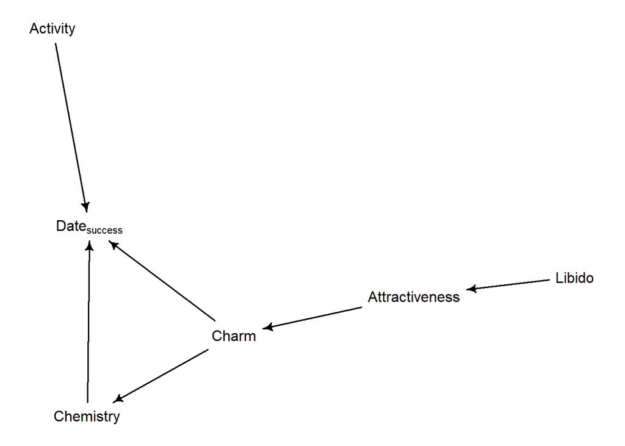

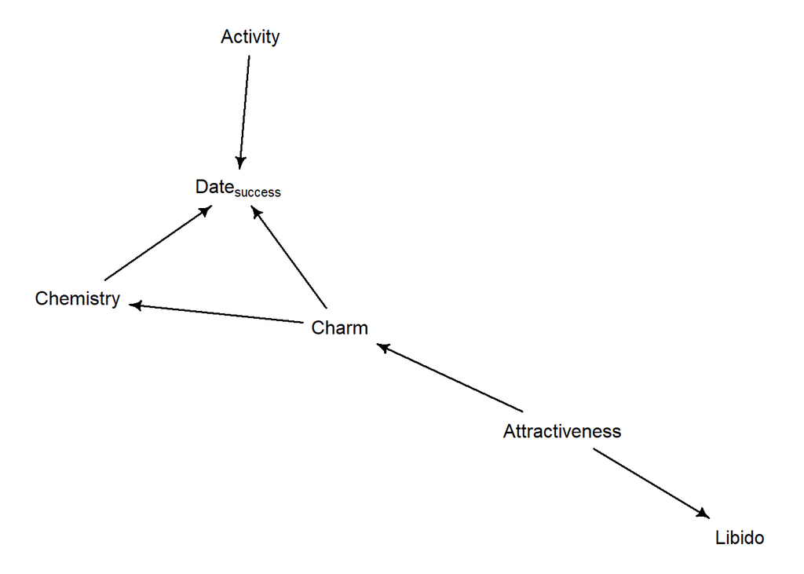

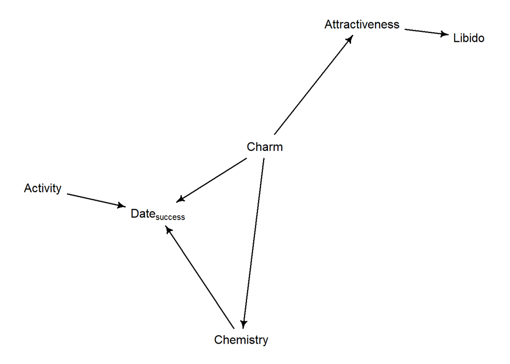

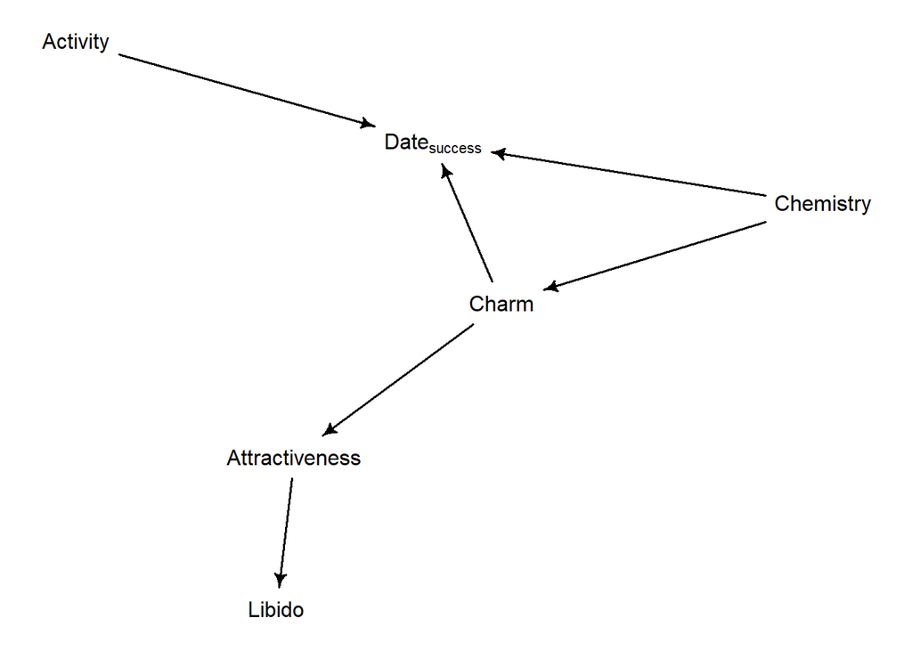

```r
equivDAGs <- equivalentDAGs(Dag)
for (dag in equivDAGs) {
  drawdag(dag)
}
```

## Task 2: The data (LR)

- **Simulate some data that fits the DAG.** There are many ways to do this. A simple way is just to sample one variable from a normal distribution which has another variable as mean. McElreath does this in the book a few times, and you can use this as inspiration.

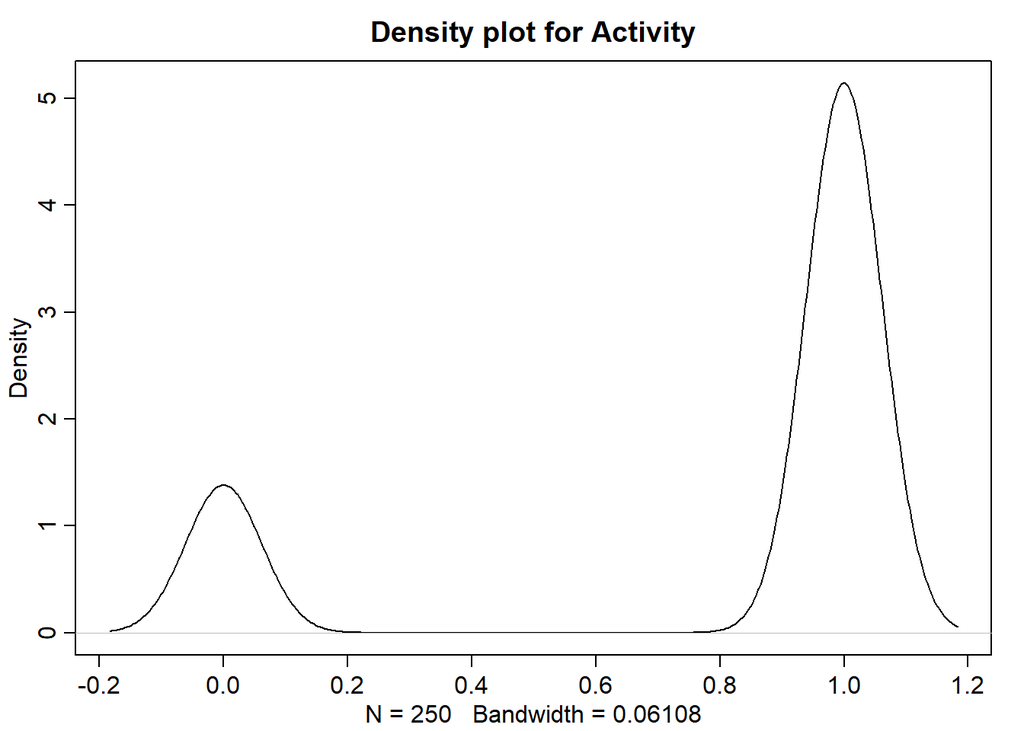

```r
# set a random seed so we report consistent results
set.seed(1337)
#Following the code on page 180 of the book, we specify the date association
n <- 250
b_ChaChe <- 0.75 # Direct effect of Charm on chemistry
b_ChaDS <- 1.5 # Direct effect of Charm on Date Success
b_CheDS <- 1 # Direct effect of Chemistry on Date Success
b_ADs <- 0.5 # Direct effect of Activity on Date Success
b_AtCha <- 0.2 # Direct effect of Attractiveness on Charm
b_LAt <- 0.7 # Direct effect of Libido on Attractiveness

# Simulate data
sLibido <- rnorm(n)
sAttractiveness <- rnorm(n, b_LAt * sLibido)
sCharm <- rnorm(n, b_AtCha * sAttractiveness)
sChemistry <- rnorm(n, b_ChaChe * sCharm)
sActivity <- rbinom(n, p = 0.79, size = 1) # Activity = 0 being bowling, 1 being Candle light dinner and go-carting
sDate_success <- rnorm(n,
  b_CheDS * sChemistry +
  b_ChaDS * sCharm +
  b_ADs * sActivity)

df <- data.frame(
  Activity = sActivity,
  Attractiveness = sAttractiveness,
  Charm = sCharm,
  Chemistry = sChemistry,
  Date_success = sDate_success,
  Libido = sLibido)

dens(df$Activity, main = "Density plot for Activity")
```

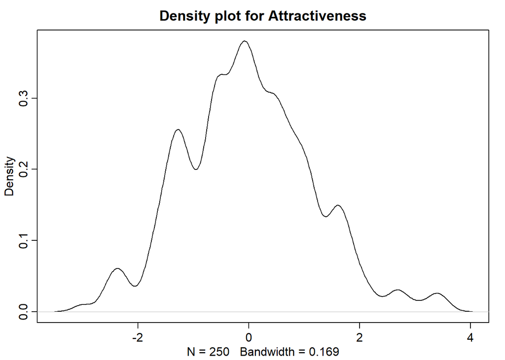

```r
dens(df$Attractiveness, main = "Density plot for Attractiveness")
```

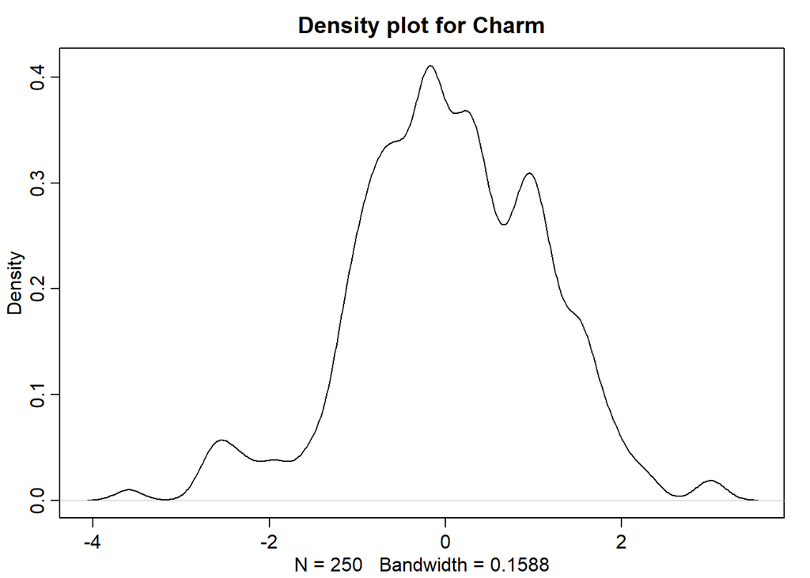

```r
dens(df$Charm, main = "Density plot for Charm")
```

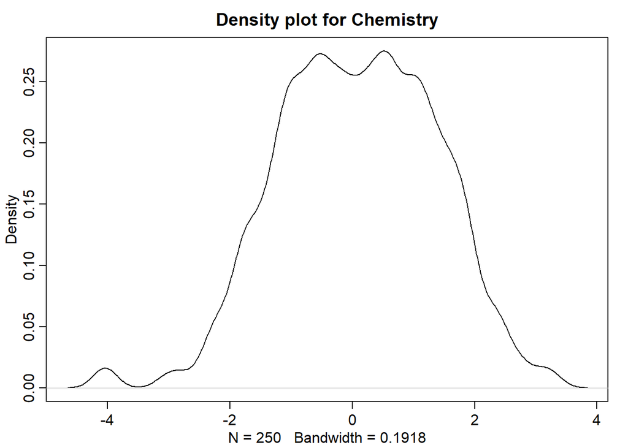

```r
dens(df$Chemistry, main = "Density plot for Chemistry")
```

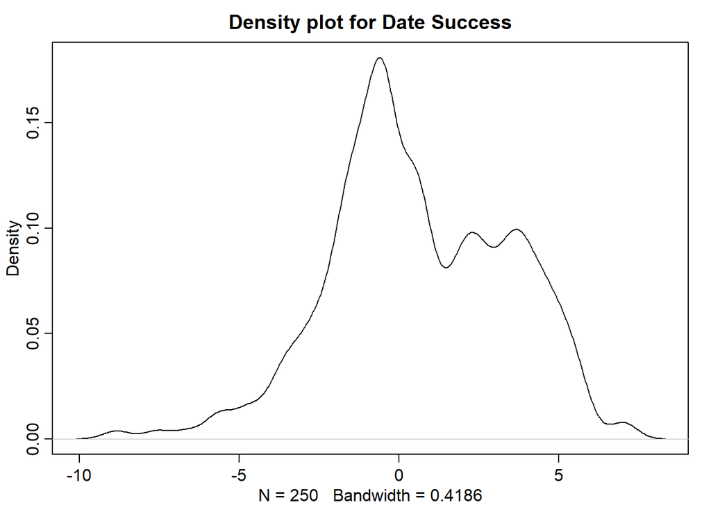

```r
dens(df$Date_success, main = "Density plot for Date Success")
```

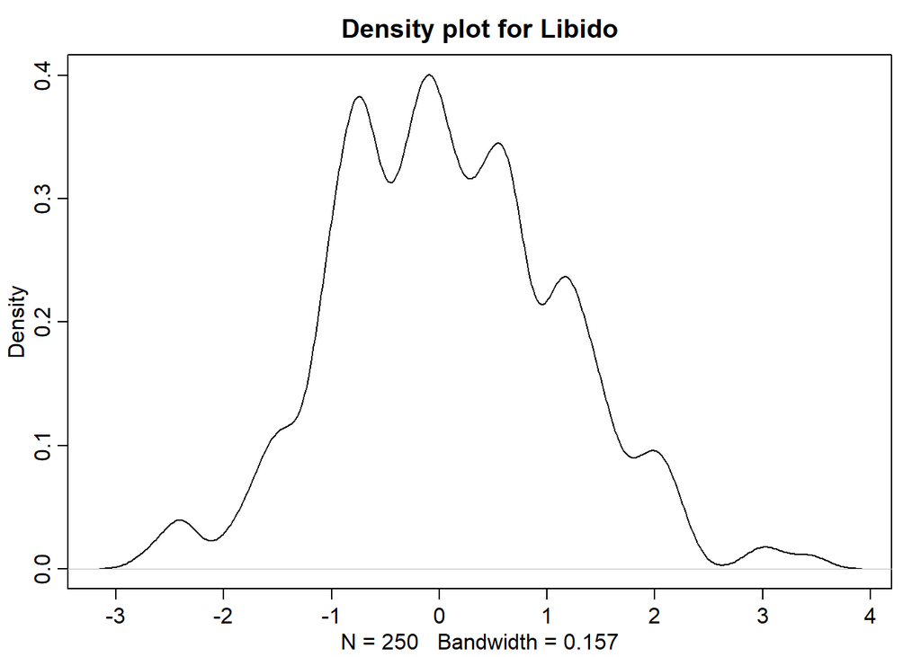

```r
dens(df$Libido, main = "Density plot for Libido")
```

```r
df$Activity <- ifelse(df$Activity == 1, 2, 1)
str(df$Activity)
```

```
 num [1:250] 2 2 2 2 2 2 2 1 2 2 ...
```

## Task 3: Statistics (VK)

- Run **multiple linear regression**s to **test the conditional independencies** **implied by your DAG**. Make sure to avoid backdoor paths. See that the linear model shows the conditional independencies implied by your DAG, implying that the data and the DAG are compatible (if the linear model doesn't show the conditional independencies implied by the DAG, the data and the DAG doesn't fit).

> Actv _||_ Attr Actv _||_ Chrm Actv _||_ Chms Actv _||_ Libd Attr _||_ Chms | Chrm Attr _||_ Dt_s | Chrm Chrm _||_ Libd | Attr Chms _||_ Libd | Attr Chms _||_ Libd | Chrm Dt_s _||_ Libd | Attr Dt_s _||_ Libd | Chrm

```r
adjustmentSets(Dag,
  exposure = "Activity",
  outcome = "Libido")
```

```
 {}
```

```r
# test independence of Activity and Libido
m1 <- quap(
  alist(
    Libido ~ dnorm(mu, sigma),
    mu <- b_ACT*Activity,
    b_ACT ~ dnorm(0, 1),
    sigma ~ dexp(1)
    ), data = df)
precis(m1, depth = 2)
```

|  | mean | sd | 5.5% | 94.5% |
| --- | --- | --- | --- | --- |
| b_ACT | 0.03109296 | 0.03617287 | -0.02671827 | 0.08890418 |
| sigma | 1.04970007 | 0.04679675 | 0.97490982 | 1.12449031 |

```r
adjustmentSets(Dag,
  exposure = c("Attractiveness", "Libido"),
  outcome = "Charm")
```

```
 {}
```

```r
# test independence of charm and libido given attractiveness
m2 <- quap(
  alist(
    Charm ~ dnorm(mu, sigma),
    mu <- b_ATTR*Attractiveness + b_LIB*Libido,
    b_ATTR ~ dnorm(0, 1),
    b_LIB ~ dnorm(0, 1),
    sigma ~ dexp(1)
    ), data = df)
precis(m2, depth = 2)
```

|  | mean | sd | 5.5% | 94.5% |
| --- | --- | --- | --- | --- |
| b_ATTR | 0.2756411012 | 0.06286834 | 0.1751654 | 0.3761168 |
| b_LIB | 0.0001268338 | 0.06953396 | -0.1110019 | 0.1112555 |
| sigma | 1.0114490914 | 0.04509725 | 0.9393750 | 1.0835232 |

```r
# Make model predicting Date Success by Charm and Chemistry
m3 <- quap(
  alist(
    Date_success ~ dnorm(mu, sigma),
    mu <- a + b_ChaDS * Charm + b_CheDS * Chemistry,
    a ~ dnorm(0, 1),
    b_ChaDS ~ dnorm(0, 1.5),
    b_CheDS ~ dnorm(0, 1),
    sigma ~ dexp(1)
    ), data = df)

precis(m3)
```

|  | mean | sd | 5.5% | 94.5% |
| --- | --- | --- | --- | --- |
| a | 0.4366302 | 0.06582300 | 0.3314324 | 0.5418281 |
| b_ChaDS | 1.4246019 | 0.07792983 | 1.3000550 | 1.5491488 |
| b_CheDS | 1.0755608 | 0.06449476 | 0.9724857 | 1.1786359 |
| sigma | 1.0408372 | 0.04640383 | 0.9666749 | 1.1149995 |

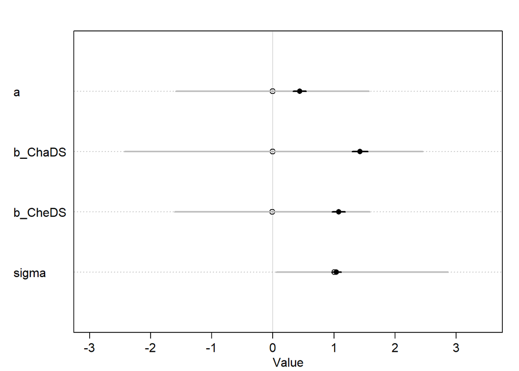

```r
# plot our priors and posteriors
prior <- extract.prior(m3, n = 1e4)
post <- extract.samples(m3)

plot(precis(prior, 2), col.ci = "gray", xlim = c(-3, 3.5))
plot(precis(post, 2), add = TRUE, pch = 16)
```

```r
# Make model predicting Date Success by Activity
m4 <- quap(
  alist(
    Date_success ~ dnorm(mu, sigma),
    mu <- a[Activity],
    a[Activity] ~ dnorm(0, 1),
    sigma ~ dexp(1)
    ), data = df)

precis(m4, depth = 2)
```

|  | mean | sd | 5.5% | 94.5% |
| --- | --- | --- | --- | --- |
| a[1] | 0.02149197 | 0.3555833 | -0.5467988 | 0.5897828 |
| a[2] | 0.72215770 | 0.1936144 | 0.4127245 | 1.0315909 |
| sigma | 2.76969962 | 0.1228573 | 2.5733500 | 2.9660493 |

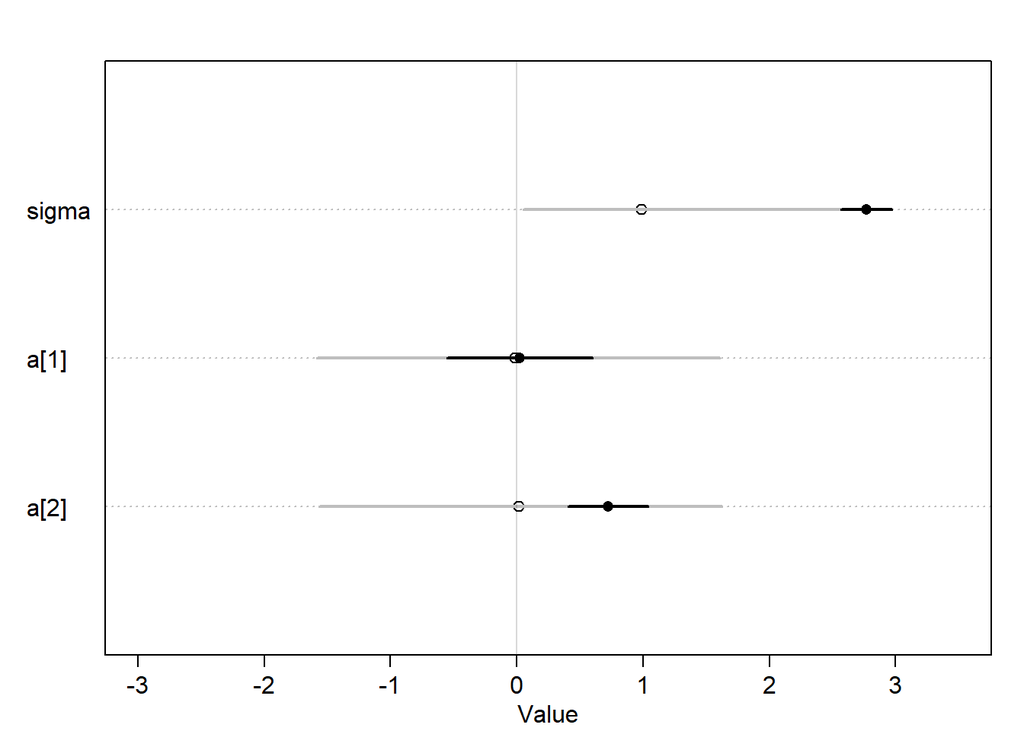

```r
# plot our priors and posteriors
prior <- extract.prior(m4, n = 1e4)
post <- extract.samples(m4)

plot(precis(prior, 2), col.ci = "gray", xlim = c(-3, 3.5))
plot(precis(post, 2), add = TRUE, pch = 16)
```

We only tested two of the conditional independencies implied by our DAG, as we considered these ones sufficient enough to test it.

## Task 4: Messing it up (KV)

- Try and **deliberately have an open back door path** and see if you can get wrong inference.

- Try and deliberately **simulate some data that doesn't fit the DAG**, or **create a new DAG that doesn't fit the data**.

- Use the same approach as above to **show that the DAG is wrong** (by showing that conditional independencies don't exist in the data, for example).

Predicting Date_Success by Chemistry without conditioning on Charm should open a back door. Let’s try that:

```r
m1.1 <- quap(
  alist(
    Date_success ~ dnorm(mu, sigma),
    mu <- a + b_CheDS * Chemistry,
    a ~ dnorm(0, 1),
    b_CheDS ~ dnorm(0, 1),
    sigma ~ dexp(1)
    ), data = df)

precis(m1.1)
```

|  | mean | sd | 5.5% | 94.5% |
| --- | --- | --- | --- | --- |
| a | 0.444847 | 0.10000571 | 0.2850186 | 0.6046754 |
| b_CheDS | 1.785679 | 0.07793541 | 1.6611229 | 1.9102346 |
| sigma | 1.585943 | 0.07059828 | 1.4731133 | 1.6987727 |

As can be seeen in outcome, the model thinks the mean of b_CheDS is 1.79 and with a SD of 0.08 seems pretty confident about it. It is however pretty far off the true value of 1.

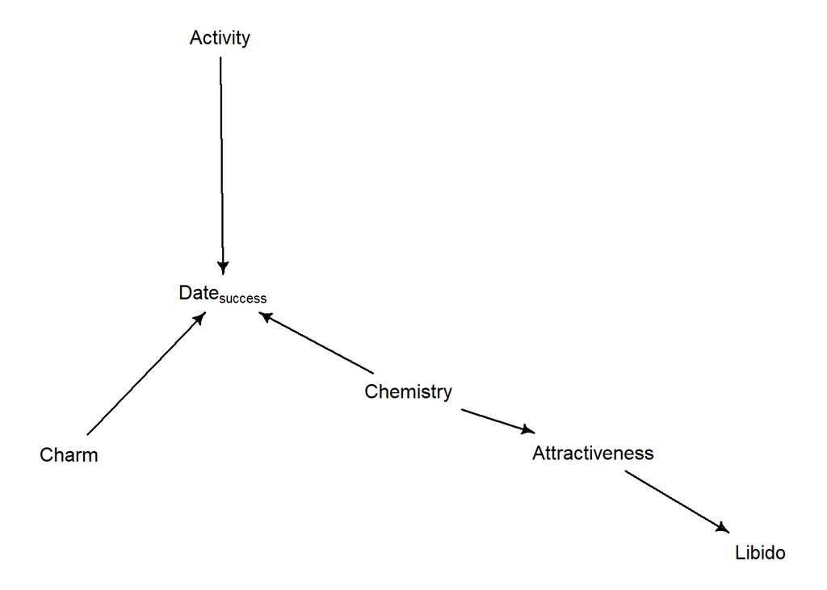

```r
Wrong_Dag <- dagitty(
  "dag {
    Chemistry -> Date_success
    Charm -> Date_success
    Activity -> Date_success
    Chemistry -> Attractiveness
    Attractiveness -> Libido
  }"
)

drawdag(Wrong_Dag)
```

So according to the new DAG Charm and Chemistry are independent of each other, which is wrong We’re gonna show this

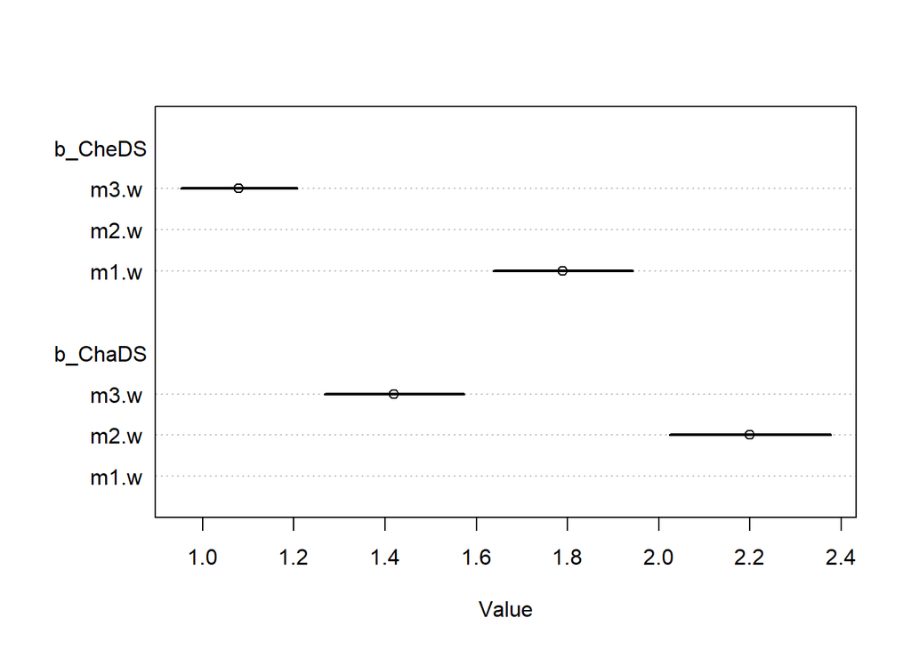

```r
# Making three models, one for each of
# the variables and one with both

# Some we already have but we'll make them again for this new DAG

m1.w <- quap(
  alist(
    Date_success ~ dnorm(mu, sigma),
    mu <- a + b_CheDS * Chemistry,
    a ~ dnorm(0, 1),
    b_CheDS ~ dnorm(0, 1),
    sigma ~ dexp(1)
    ), data = df)

m2.w <- quap(
  alist(
    Date_success ~ dnorm(mu, sigma),
    mu <- a + b_ChaDS * Charm,
    a ~ dnorm(0, 1),
    b_ChaDS ~ dnorm(0, 1),
    sigma ~ dexp(1)
    ), data = df)

m3.w <- quap(
  alist(
    Date_success ~ dnorm(mu, sigma),
    mu <- a + b_ChaDS * Charm + b_CheDS * Chemistry,
    a ~ dnorm(0, 1),
    b_ChaDS~ dnorm(0, 1),
    b_CheDS ~ dnorm(0, 1),
    sigma ~ dexp(1)
    ), data = df)

plot(coeftab(m1.w, m2.w, m3.w), pars = c("b_CheDS", "b_ChaDS"))
```

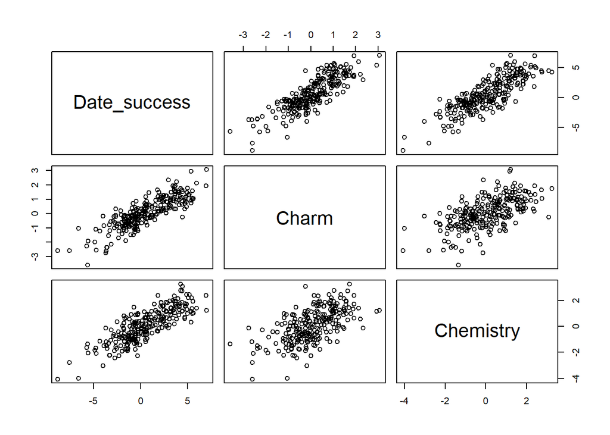

```r
pairs(~Date_success + Charm + Chemistry, df)
```

As seen in the plots and the regressions (which is pretty much the same as the ones from earlier) we can see that the variables are not independent as suggested by the Wrong_DAG.

This is supported by the fact that the beta-means shift around so much when conditioning on both Chemistry and Charm. Plus if one looks as the Pairs-plot the variables are highly colinear and the regression is not very good.